[figure not shown]

# Using the COGITATE iEEG data

Welcome to the COGITATE Consortium's iEEG Data Exploration Notebook! In this tutorial, we will guide you through the process of accessing and analyzing intracranial electroencephalography (iEEG) data collected as part of our consortium. The COGITATE consortium is an adversarial collaboration (Melloni et al., 2023, COGITATE et al., 2023) aiming to deepen our understanding of consciousness by comparing two prominent theories: Integrated Information Theory (IIT) (Albantakis et al., 2023) and Global Neuronal Workspace (GNW) (Mashour et al., 2020).

The dataset we are sharing originates from experiments employing a carefully designed paradigm. Participants were presented with images from four distinct categories (faces, objects, letters and symbols), each displayed at three different orientations (center, left, and right). Furthermore, these images were shown for varying durations of 0.5, 1.0, and 1.5 seconds. At the beginning of each experimental block, participants were shown two specific target identities, representing either a specific face and a specific object. Participants were tasked with pressing a button when these target identities appeared. This introduced an additional task relevance condition: stimuli of the same category as the targets but of a different identity were deemed task-relevant, while stimuli from other categories were considered task-irrelevant. This comprehensive experimental design allows us to delve into the neural correlates of consciousness across different stimuli and temporal conditions while controlling for task demands (for more details, see Melloni et al., 2023).

This notebook serves a dual purpose: to provide a user-friendly guide on how to navigate, load, preprocess, and access specific data within our dataset, and to introduce the basics of iEEG data analysis. We will walk you through a simple univariate analysis, offering insights into individual channels, and a basic multivariate analysis, shedding light on the complex interplay of neural signals.

## Learning objectives

By the end of this tutorial, you will:

- Understand how to load and preprocess iEEG data from the COGITATE consortium
- Access and index specific data based on experimental conditions
- Perform a simple univariate analysis to examine the response patterns of individual channels
- Engage in a basic multivariate analysis to uncover relationships and patterns across multiple channels

## Disclaimer:

This notebook does not aim to replicate the analysis of the COGITATE consortium analyses (COGITATE et al., 2023) but rather guide users to use our data. The code to replicate the results will be shared here.

```python
# Setting all modules:
from pathlib import Path
import scipy
import mne
import json
from mne.viz import plot_alignment, snapshot_brain_montage
from mne_bids import BIDSPath, read_raw_bids
import numpy as np
import matplotlib.pyplot as plt
from matplotlib import colormaps
from pingouin import ttest

from pipelines.Preprocessing import preprocessing
from pipelines.OnsetResponsiveness import onset_responsiveness
from pipelines.Decoding import decoding
from HelperFunctions import get_roi_channels, create_mni_montage, get_cmap_rgb_values

import environment_variables as ev

# Fetch the fsaverage brain surface to plot the electrodes localization across subjects
fs_average_dir = Path(mne.datasets.sample.data_path(), 'subjects')
# use mne-python's fsaverage data
mne.datasets.fetch_fsaverage(subjects_dir=fs_average_dir, verbose=True)  # downloads if needed
```

```
0 files missing from root.txt in C:\Users\alexander.lepauvre\mne_data\MNE-sample-data\subjects
0 files missing from bem.txt in C:\Users\alexander.lepauvre\mne_data\MNE-sample-data\subjects\fsaverage
```

```
'C:\\Users\\alexander.lepauvre\\mne_data\\MNE-sample-data\\subjects\\fsaverage'
```

## Set up and download of the BIDS converted data

The first step is to specify the data that we will be working with, as well as the place to store them on the local machine. All path are specified under environment_variable.py. Make sure to edit this file to match your computer. For the purpose of this notebook, we will download the data of the first of the COGITATE for a couple of subjects.

```python
# Print the path to the different data:
print("The following path are specified")
print("raw data root: ")
print("   {}".format(ev.raw_root))
print("bids root: ")
print("   {}".format(ev.bids_root))
print("freesurfer directory: ")
print("   {}".format(ev.fs_directory))
print("If this does not match what you expect, make sure to change the path under iEEG-data-release/environment_variable.py")

# Specify the subjects to work with:
subjects_list = ["CF102"]
# Further specify the data to use from the subjects:
session = "V1"
datatype = "ieeg"
task = "Dur"

# Create the mne bids path object, making access to the data easier. We will use one example subject to demonstrate the details of our analyses.
bids_path = BIDSPath(root=ev.bids_root, subject=subjects_list[0],
                     session='V1',
                     datatype='ieeg',
                     task='Dur')
```

```
The following path are specified
raw data root:
   C:\Users\alexander.lepauvre\Documents\GitHub\iEEG-data-release\data_release\raw
bids root:
   C:\Users\alexander.lepauvre\Documents\GitHub\iEEG-data-release\data_release\bids
freesurfer directory:
   C:\Users\alexander.lepauvre\Documents\GitHub\iEEG-data-release\data_release\bids\derivatives\fs
If this does not match what you expect, make sure to change the path under iEEG-data-release/environment_variable.py
```

As the data are organized according to the BIDS specification, we can use the mne bids functionalities to load the data, which we will showcase with one test subject.

```python
%%capture
# Loading the data under the term broadband, as it is what they are as long as no further
# filtering was employed
raw = read_raw_bids(bids_path=bids_path, verbose=True);
```

Now that the data are lodaded, we can inspect them by plotting the power spectrum density as well as the electrodes localization on the brain surface.

```python
%%capture
# Compute and plot the PSD:
raw.compute_psd().plot(picks='data', exclude='bads', spatial_colors=False)

# Plot the channels localization on the subject's pial surface.
fig = plot_alignment(
    info=raw.info,
    trans="fsaverage",
    subject=subjects_list[0],
    subjects_dir=ev.fs_directory,
    surfaces=["pial"],
    coord_frame="head",
    ecog=True,
    seeg=False,
    sensor_colors=sensor_colors,
)
```

## Running the preprocessing

The BIDS downloaded data can then be preprocessed. The various pipelines in this notebook have many parameters. Default parameters are stored in json files alongside extensive documentation for each option. The default parameters for the preprocessing apply the following steps to the data:

- Removal of bad channels
- Notch filtering to remove line noise (60Hz)
- Re-referencing using Laplace scheme
- High gamma computations (70-150Hz)
- ERP computations (0-30Hz)
- Epoching

The preprocessing pipeline take as input either the path to the parameter json file or a dictionary specifying the processing options. We can load the parameters file to see what the default parameters of the preprocessing are:

```python
# Loading the parameters:
with open("pipelines/preprocessing_config-default.json") as f:
    param = json.load(f)
# Display the default processing steps:
[print(param["preprocessing_steps"][i]) for i in range(len(param["preprocessing_steps"]))];
```

```
plot_channels_loc
description_bad_channels_rejection
notch_filtering
laplace_reference
atlas_mapping
hg_computations
erp_computations
epoching
```

The default preprocessing pipeline applies the step described above (in addition, it plots the channels location, which is a data vizualization step not affecting the data themselves). For each of these steps, we have a set of options. Let's have a look:

```python
# Show two example steps parameters:
print("Notch filtering parameters")
print(param["notch_filtering"])
```

```
Notch filtering parameters
{'broadband': {'channel_types': {'ecog': True, 'seeg': True, 'exclude': 'bads'}, 'frequency': 60, 'remove_harmonics': True, 'filter_type': 'fir', 'cutoff_lowpass_bw': 63, 'cutoff_highpass_bw': 57}}
```

In the case of the notch filtering, the 'broadband' key specifies which signal on which the filtering should be applied (in this case the non-filtered raw data, i.e. the broadband signal). Within this dictionary, the channel_types key specifies which type of channels the filtering should be applied. There are then several additional parameters controlling the filtering parameters themselves (make sure to the check out the entire documentation). If you wish to change one option, such as the frequency to filter out, you simply edit the dictionary. Similarly, if you wish to skip a step, you can remove it from the list of performed steps:

```python
# How to adjust the filtered out frequency:
param["notch_filtering"]["broadband"]["frequency"] = 50
print("New filtering frequency: ")
print(param["notch_filtering"])

# How to skip a step:
param["preprocessing_steps"].remove("laplace_reference")
print("")
print("New preprocessing steps: ")
[print(param["preprocessing_steps"][i]) for i in range(len(param["preprocessing_steps"]))];
```

```
New filtering frequency:
{'broadband': {'channel_types': {'ecog': True, 'seeg': True, 'exclude': 'bads'}, 'frequency': 50, 'remove_harmonics': True, 'filter_type': 'fir', 'cutoff_lowpass_bw': 63, 'cutoff_highpass_bw': 57}}

New preprocessing steps:
plot_channels_loc
description_bad_channels_rejection
notch_filtering
atlas_mapping
hg_computations
erp_computations
epoching
```

The processing pipeline script takes as input either the path to the json file containing the parameters or the loaded dictionary directly. Editing the preprocessing paramters by editing a dictionary is handy to try different option. We however recommend creating a copy of the default parameters file once you have settled on a set of parameters for reproducibility. Note that the set of parameters that were used are saved alongside the files generated by the preprocessing pipeline, making it easy to trace back the set of used parameters.

For the sake of speed, we will deactivate the plotting options for this run

```python
# Loading the parameters:
with open("pipelines/preprocessing_config-default.json") as f:
    param = json.load(f)
param["check_plots"] = False
param["plot_single_channels"] = False
preprocessing(param, subjects_list)
```

```
================================================================================
Welcome to preprocessing!
The following subjects will now be preprocessed:
['CF102']
It may take some time, count roughly 5-10min per subject!
================================================================================
Preprocessing CF102
```

[output not shown]

[output cut: 57 more lines]

[output not shown]

[output not shown]

### Visualizing the preprocessed data

The final output of the preprocessing pipeline are the epoched data. The naming conventions of the folders follow the BIDS conventions You can therefore load the data as follows, and plot a single channel using mne functionalities

```
Reading C:\Users\alexander.lepauvre\Documents\GitHub\iEEG-data-release\data_release\bids\derivatives\preprocessing\sub-CF102\ses-V1\ieeg\epoching\high_gamma\sub-CF102_ses-V1_task-Dur_desc-epoching_ieeg-epo.fif ...
    Found the data of interest:
        t =    -750.00 ...    2500.00 ms
        0 CTF compensation matrices available
Adding metadata with 9 columns
1440 matching events found
No baseline correction applied
0 projection items activated
Not setting metadata
1440 matching events found
No baseline correction applied
0 projection items activated
```

```
[<Figure size 640x480 with 4 Axes>]
```

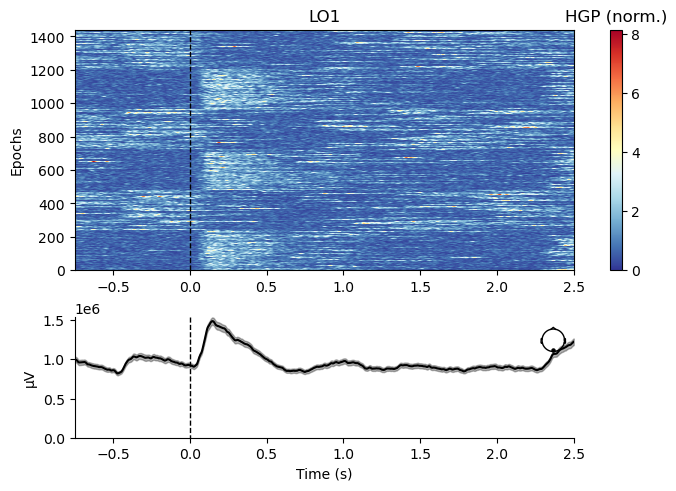

```python
channel = 'LO1'
example_epochs_path = Path(ev.bids_root, 'derivatives', 'preprocessing',
                           'sub-' + subjects_list[0], 'ses-' + "V1", 'ieeg',
                           "epoching", 'high_gamma',
                           "sub-{}_ses-{}_task-{}_desc-epoching_{}-epo.fif".format(subjects_list[0],
                                                                                   "V1", "Dur",
                                                                                   "ieeg"))

epochs = mne.read_epochs(example_epochs_path, preload=True)
mne.viz.plot_epochs_image(epochs, picks=channel,
                          show=False, units=dict(ecog="HGP (norm.)", seeg="HGP (norm.)"),
                          scalings=dict(ecog=1, seeg=1),
                          evoked=True, cmap="RdYlBu_r")
```

Notice that the figure above looks odd, with some activation in the baseline. That is because we have data that are epochs relative to both the onset and the offset of the stimuli for different analyses. For most purpose, we would need to select only the epochs locked to stimulus onset. This can be achieved by selecting the epochs by conditions, like so:

```
Not setting metadata
720 matching events found
No baseline correction applied
0 projection items activated
```

```
[<Figure size 640x480 with 4 Axes>]
```

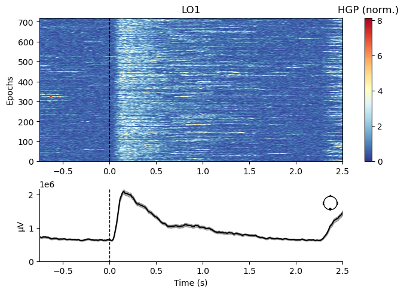

```python
onset_locked_epochs = epochs['stimulus onset']
mne.viz.plot_epochs_image(onset_locked_epochs, picks=channel,
                          show=False, units=dict(ecog="HGP (norm.)", seeg="HGP (norm.)"),
                          scalings=dict(ecog=1, seeg=1),
                          evoked=True, cmap="RdYlBu_r")
```

```
Not setting metadata
320 matching events found
No baseline correction applied
0 projection items activated
```

```
[<Figure size 640x480 with 4 Axes>]
```

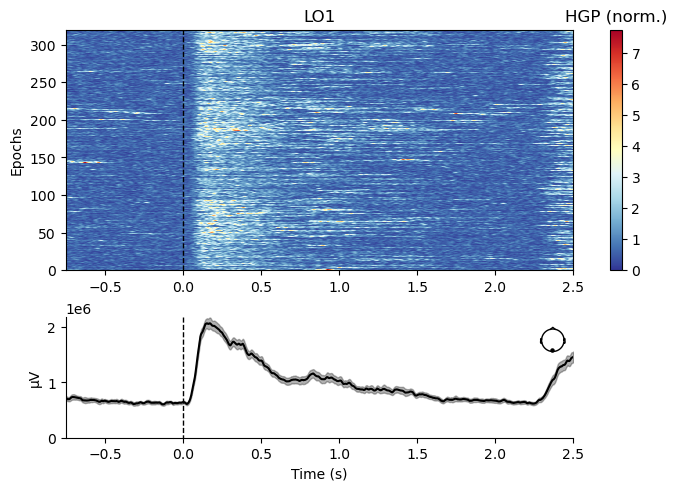

```python
task_relevant_epochs = epochs['stimulus onset/Relevant non-target']
mne.viz.plot_epochs_image(task_relevant_epochs, picks=channel,
                          show=False, units=dict(ecog="HGP (norm.)", seeg="HGP (norm.)"),
                          scalings=dict(ecog=1, seeg=1),
                          evoked=True, cmap="RdYlBu_r")
```

```
Not setting metadata
26 matching events found
No baseline correction applied
0 projection items activated
```

```
[<Figure size 640x480 with 4 Axes>]
```

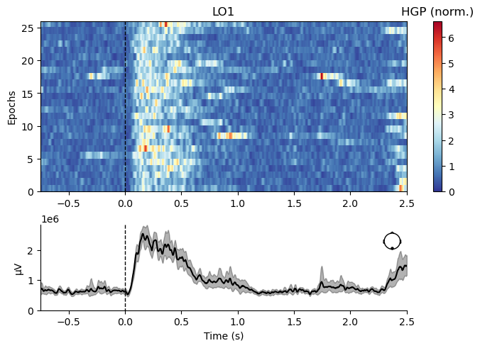

```python
task_relevant_face_short_epochs = epochs['stimulus onset/Relevant non-target/face/500ms']
mne.viz.plot_epochs_image(task_relevant_face_short_epochs, picks=channel,
                          show=False, units=dict(ecog="HGP (norm.)", seeg="HGP (norm.)"),
                          scalings=dict(ecog=1, seeg=1),
                          evoked=True, cmap="RdYlBu_r")
```

## Onset responsiveness

Practically, we will first extract the trials locked to the onset of the stimuli and remove the target trials (as these require participants responses). We will then extract the pre (-0.3 to 0 sec. from stimulus onset) and post-stimulus (0.05 to 0.35 sec.) presentation segments for each trial. The data within each segment will be aggregated by computing the area under the curve (np.trapz). Finally, we will use the pingouin function ttest with the Cauchy scale factor set to 0.707 (default value in pingouin).

We will first show an example on a single channel then proceed to show how to run it on all electrodes of selected subjects.

```
T-test results:
   T-stat=-59.858
   p-value=0.0
   BF=9.324e+259
   df=639
```

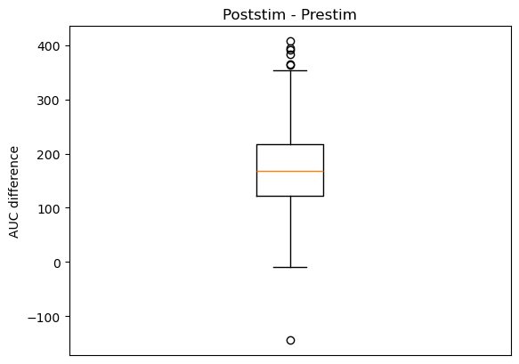

```python
# Select the trials of interest:
onset_responsiveness_data =  epochs[["stimulus onset/Irrelevant", "stimulus onset/Relevant non-target"]]
# Crop the data:
prestim_data = np.squeeze(onset_responsiveness_data.copy().crop(tmin=-0.3, tmax=0).get_data(picks='LO1'))
poststim_data = np.squeeze(onset_responsiveness_data.copy().crop(tmin=0.05, tmax=0.350).get_data(picks='LO1'))
# Compute the AUC:
prestim_auc = np.trapz(prestim_data, axis=1)
poststim_auc = np.trapz(poststim_data, axis=1)
# Perform a two sided paired t-test:
results = ttest(prestim_auc, poststim_auc, paired=True, r=0.707, alternative='two-sided').round(3)

# Showing the results of the test:
print('T-test results:')
print('   T-stat={}'.format(results['T'].item()))
print('   p-value={}'.format(results['p-val'].item()))
print('   BF={}'.format(results['BF10'].item()))
print('   df={}'.format(results['dof'].item()))
fig, ax = plt.subplots()
ax.boxplot(poststim_auc - prestim_auc)
ax.set_title('Poststim - Prestim')
ax.set_xticks([])
ax.set_xticklabels([])
ax.set_ylabel('AUC difference')
```

As we can see, the difference between pre and post-stimulus window is positive, indicating that HG activation is larger after stimulus onset. Accordingly, the bayes factor is really large, indicating that we have very strong evidence that this channel is responsive to our experimental paradigm.

### Onset responsiveness pipeline

This function further takes two additional inputs:

- plot_single_channels: boolean flag to plot single electrodes or not
- plot_only_responsive: boolean flag to plot only those channels that were found to have differences in activation compared to baseline.

Single channels plotting can take a long time, so you might want to deactivate it.

```python
%%capture
config_file = "pipelines/onset_responsiveness_config-default.json"
results = onset_responsiveness(config_file, subjects_list[0], plot_single_channels=False, plot_only_responsive=False)
```

### Investigate the results

The pipeline generates a dataframe containing the results of the onset responsiveness test, with one row per channel, with the results of the test in the columns: Now that we have ran the onset responsiveness analysis, we can provide some summary statistics for the data.

```python
print(results.head())
```

```
  subject   channel  statistic  pvalue            bf  reject     df  lowCI  \
0   CF102  CF102-G1      3.017   0.003  3.999000e+00    True  639.0   1.15
1   CF102  CF102-G2      0.840   0.401  6.300000e-02   False  639.0  -1.27
2   CF102  CF102-G3     -2.230   0.026  5.230000e-01   False  639.0  -4.76
3   CF102  CF102-G5     -6.511   0.000  3.332000e+07    True  639.0  -7.76
4   CF102  CF102-G6     -0.897   0.370  6.600000e-02   False  639.0  -2.82

   highCI    f_size
0    5.43 -0.119357
1    3.18 -0.033211
2   -0.30  0.088216
3   -4.17  0.257587
4    1.05  0.035488
```

We can investigate the results to assess how many electrodes show a change in activation, and for how many activation increases and decreases compared to the baseline period

```python
# Channels counts:
responsive_channels = results[results['reject'] == True]
activated_channels = results[(results['reject'] == True) & (results['f_size'] > 0)]
deactivated_channels = results[(results['reject'] == True) & (results['f_size'] < 0)]
# Print the counts:
print("{} out of {} ({:.2f}%) were found to be onset responsive!".format(
    responsive_channels.shape[0],
    results.shape[0],
    responsive_channels.shape[0] / results.shape[0] * 100))
print("{} out of {} ({:.2f}%) showed an increase of activation following  stimulus onset!".format(
    activated_channels.shape[0],
    results.shape[0],
    activated_channels.shape[0] / results.shape[0] * 100
))
print("{} out of {} ({:.2f}%) showed an decrease of activation following  stimulus onset!".format(
    deactivated_channels.shape[0],
    results.shape[0],
    deactivated_channels.shape[0] / results.shape[0] * 100
))
```

```
22 out of 81 (27.16%) were found to be onset responsive!
15 out of 81 (18.52%) showed an increase of activation following  stimulus onset!
7 out of 81 (8.64%) showed an decrease of activation following  stimulus onset!
```

We can also further investigate the results by looking at each subject separately:

```python
subjects_channels_counts = results.groupby(["subject", "reject"]).count().reset_index()[["subject", "reject", "channel"]]
# Print the counts:
print(subjects_channels_counts.loc[subjects_channels_counts["reject"] == True, ["subject", "channel"]])
```

```
  subject  channel
1   CF102       22
```

### Plotting responsive channels on the brain surface

One important sanity check is to make sure that the localization of the effects make sense. As the task in the COGITATE was visual, one would expect to find a lot of onset responsive electrodes over the posterior cortex. To check whether that is the case, we will extract only the onset responsive electrodes that we hve identified above and we will plot that on the pial surface.

```
Channel types::	ecog: 22
```

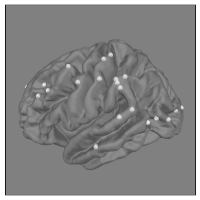

```python
# Extract the onset responsive electrodes:
onset_responsive_results = results.loc[results["reject"] == True]
# Get these channels localization in MNI space:
mni_info = create_mni_montage(onset_responsive_results["channel"].to_list(), bids_path, ev.fs_directory, fs_average_dir)

# We can now go ahead and plot the ecog channels on the brain:
# Plot the ecog:
fig = plot_alignment(
    info=mni_info,
    trans="fsaverage",
    subject="fsaverage",
    subjects_dir=fs_average_dir,
    surfaces=["pial"],
    coord_frame="head",
    ecog=True,
    seeg=False,
    sensor_colors=[[1.0, 1.0, 1.0, 0.8]] * len(mni_info.ch_names),
)
mne.viz.set_3d_view(fig, azimuth=180, elevation=70, focalpoint="auto", distance=0.4)
xy, im = snapshot_brain_montage(fig, mni_info)
fig2, ax2 = plt.subplots()
ax2.imshow(im)
ax2.yaxis.set_visible(False)
ax2.xaxis.set_visible(False)
plt.show()
```

Additionally, not only do we expect more channels to be responsive in posterior regions, we also expect the effects to be stronger. To vizualize this, you can plot the effect sizes of the onset responsiveness on the brain.

```
Channel types::	ecog: 22
```

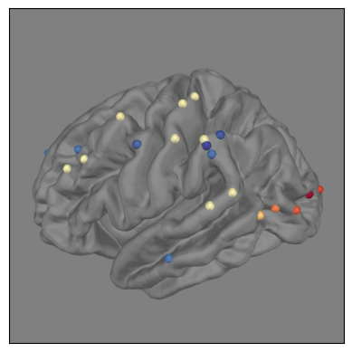

```python
# Extract the effect sizes:
f_sizes = onset_responsive_results["f_size"].to_list()

# Get the RGB values for effect sizes mapped onto a colormap<
sensor_colors = get_cmap_rgb_values(f_sizes, cmap=None, center=0)

# We can now go ahead and plot the dig montage on the brain:
fig = plot_alignment(
    info=mni_info,
    trans="fsaverage",
    subject="fsaverage",
    subjects_dir=fs_average_dir,
    surfaces=["pial"],
    coord_frame="head",
    ecog=True,
    seeg=False,
    sensor_colors=sensor_colors,
)
mne.viz.set_3d_view(fig, azimuth=180, elevation=70, focalpoint="auto", distance=0.4)

xy, im = snapshot_brain_montage(fig, mni_info)
xy_pts = np.vstack([xy[ch] for ch in mni_info.ch_names])
fig2, ax2 = plt.subplots()
ax2.imshow(im)
ax2.yaxis.set_visible(False)
ax2.xaxis.set_visible(False)
plt.show()
```

The colorbar is centered on 0, such that channels showing an increase in effect size are plotted in yellow/red tones while the channels showing a decrease in activation are plotted in blueish tones. As is to be expected, the channels located in occipital regions show the strongest effect sizes, but onset responsive electrodes can be found in several cortical locations

### Investigate specific regions of interest

```
WARNING: No loc for G33
WARNING: EKG1 not found in channels localization file
WARNING: EKG2 not found in channels localization file
The following channels were found in the ROI
['LO1', 'LO2', 'LO4', 'LO5']
Channel types::	ecog: 4
```

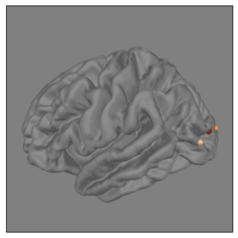

```python
# Define the list of regions of interest:
rois = ["Pole_occipital",
        "G_occipital_middle",
        "G_cuneus",
       ]
# Extract the channels within this ROI:
roi_channels = get_roi_channels(epochs.ch_names, rois, bids_path, 'aparc.a2009s+aseg')
print('The following channels were found in the ROI')
print(roi_channels)
# Extract the onset responsiveness results for the channels only:
roi_onset_responsiveness = results.loc[results['channel'].isin(['-'.join([subjects_list[0], channel]) for channel in roi_channels])]
channels_counts = roi_onset_responsiveness.groupby("reject").count().reset_index()[["reject", "channel"]]

# Create a montage for these channels alone:
roi_mni_info = create_mni_montage(roi_onset_responsiveness["channel"].to_list(), bids_path, ev.fs_directory, fs_average_dir)

# Extract the effect sizes:
roi_f_sizes = roi_onset_responsiveness["f_size"].to_list()

# Get the RGB values for effect sizes mapped onto a colormap
roi_sensor_colors = get_cmap_rgb_values(roi_f_sizes, cmap="Oranges", center=None)

# We can now go ahead and plot the dig montage on the brain:
fig = plot_alignment(
    info=roi_mni_info,
    trans="fsaverage",
    subject="fsaverage",
    subjects_dir=fs_average_dir,
    surfaces=["pial"],
    coord_frame="head",
    ecog=True,
    seeg=False,
    sensor_colors=roi_sensor_colors,
)
mne.viz.set_3d_view(fig, azimuth=180, elevation=70, focalpoint="auto", distance=0.4)

xy, im = snapshot_brain_montage(fig, mni_info)
xy_pts = np.vstack([xy[ch] for ch in mni_info.ch_names])
fig2, ax2 = plt.subplots()
ax2.imshow(im)
ax2.yaxis.set_visible(False)
ax2.xaxis.set_visible(False)
plt.show()
```

## Decoding

In addition to investigate the univariate responses of every single channel, we can also performed a multivariate analysis, investigating the presence of representation of particular contrasts of interests across the electrodes in our sample. In the current example, we will use support vector machine to decode faces vs. objects across all electrodes within our example subject.

We will perform temporal generalization decoding using support vector machine for the faces vs objects labels in the task irrelevant trials. We will first prepare the data by selecting only seeg and ecog channels, downsample the data and select the conditions of interest. We will then create a classifier and apply it to our data with 5 fold cross validation and score the decoding accuracy using roc_auc.

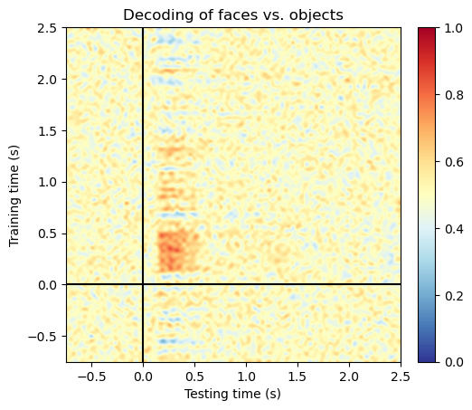

```python
# Import the required libraries:
from sklearn.pipeline import make_pipeline
from sklearn import svm
from sklearn.preprocessing import StandardScaler
from sklearn.feature_selection import SelectKBest, f_classif
from mne.decoding import (GeneralizingEstimator, cross_val_multiscore)


#Select electrodes:
picks = mne.pick_types(epochs.info, ecog=True, seeg=True)
decoding_epochs = epochs.copy().pick(picks)
# Downsample:
decoding_epochs.resample(30, n_jobs=1)
# Select trials:
decoding_epochs = decoding_epochs[["stimulus onset/Irrelevant/face", "stimulus onset/Irrelevant/object"]]

# Create the classifier:
clf_steps = []
clf_steps.append(StandardScaler())
clf_steps.append(svm.SVC(kernel='linear', class_weight='balanced'))
clf = make_pipeline(*clf_steps)
# Temporal generalization estimator:
time_gen = GeneralizingEstimator(clf, n_jobs=1, scoring='roc_auc',
                                 verbose="ERROR")

# Extract the data:
data = decoding_epochs.get_data()
# Get the classes:
y = decoding_epochs.metadata["category"].values
# Run the decoding:
scores = cross_val_multiscore(time_gen, data, y, cv=5, n_jobs=None)

# Plot the results:
fig, ax = plt.subplots()
# Plot matrix with transparency:
im = ax.imshow(np.mean(scores, axis=0), cmap="RdYlBu_r",
               extent=[epochs.times[0], epochs.times[-1], epochs.times[0], epochs.times[-1]],
               origin="lower",  # aspect="equal",
               interpolation="lanczos", vmin=0, vmax=1)
# Add the axis labels and so on:
ax.set_xlim([epochs.times[0], epochs.times[-1]])
ax.set_ylim([epochs.times[0], epochs.times[-1]])
ax.set_xlabel("Testing time (s)")
ax.set_ylabel("Training time (s)")
ax.set_title("Decoding of {}".format("faces vs. objects"))
ax.axvline(0, color='k')
ax.axhline(0, color='k')
fig.colorbar(im, fraction=0.046, pad=0.04)
```

### Decoding pipeline

```python
config_file = "pipelines/decoding_config-default.json"
scores = decoding(config_file, subjects_list)
```

```
----------------------------------------
Welcome to Decoding!
The onset responsive channels of the following subjects will be determined:
['CF102']
Using the config file:
pipelines/decoding_config-default.json
----------------------------------------
Decoding CF102 with config file pipelines/decoding_config-default.json
Reading C:\Users\alexander.lepauvre\Documents\GitHub\iEEG-data-release\data_release\bids\derivatives\preprocessing\sub-CF102\ses-V1\ieeg\epoching\high_gamma\sub-CF102_ses-V1_task-Dur_desc-epoching_ieeg-epo.fif ...
    Found the data of interest:
        t =    -750.00 ...    2500.00 ms
        0 CTF compensation matrices available
Adding metadata with 9 columns
1440 matching events found
No baseline correction applied
0 projection items activated
Decoding category with 5 folds stratified cross validation:
```

### Decoding within regions of interest

In the case of decoding, it is especially relevant to be able to investigate spatial specificy. This can be achieved as shown in the onset responsiveness analysis by pre-selecting channels based on their anatomical labels. We will here show how to do so by selecting channels located within a posterior ROI defined by the following labels:

```python
rois = ["Pole_occipital",
        "G_occipital_middle",
        "G_cuneus",]
# Extract the channels within this ROI:
roi_channels = get_roi_channels(epochs.ch_names, rois, bids_path, 'aparc.a2009s+aseg')
print('The following channels were found in the ROI')
print(roi_channels)

# Selecting those channels only:
roi_epochs = epochs.copy().pick(roi_channels)
# Downsample:
roi_epochs.resample(30, n_jobs=1)
# Select trials:
roi_epochs = roi_epochs[["stimulus onset/Irrelevant/face", "stimulus onset/Irrelevant/object"]]

# Create the classifier:
clf_steps = []
clf_steps.append(StandardScaler())
clf_steps.append(svm.SVC(kernel='linear', class_weight='balanced'))
clf = make_pipeline(*clf_steps)
# Temporal generalization estimator:
time_gen = GeneralizingEstimator(clf, n_jobs=1, scoring='roc_auc',
                                 verbose="ERROR")

# Extract the data:
data = roi_epochs.get_data()
# Get the classes:
y = roi_epochs.metadata["category"].values
# Run the decoding:
scores = cross_val_multiscore(time_gen, data, y, cv=5, n_jobs=None)

# Plot the results:
fig, ax = plt.subplots()
# Plot matrix with transparency:
im = ax.imshow(np.mean(scores, axis=0), cmap="RdYlBu_r",
               extent=[epochs.times[0], epochs.times[-1], epochs.times[0], epochs.times[-1]],
               origin="lower",  # aspect="equal",
               interpolation="lanczos", vmin=0, vmax=1)
# Add the axis labels and so on:
ax.set_xlim([epochs.times[0], epochs.times[-1]])
ax.set_ylim([epochs.times[0], epochs.times[-1]])
ax.set_xlabel("Testing time (s)")
ax.set_ylabel("Training time (s)")
ax.set_title("Decoding of {}".format("faces vs. objects"))
ax.axvline(0, color='k')
ax.axhline(0, color='k')
fig.colorbar(im, fraction=0.046, pad=0.04)
```

[output not shown]

# References

- Melloni, L., Mudrik, L., Pitts, M., Bendtz, K., Ferrante, O., Gorska, U., ... & Tononi, G. (2023). An adversarial collaboration protocol for testing contrasting predictions of global neuronal workspace and integrated information theory. Plos one, 18(2), e0268577.
- Cogitate Consortium, Ferrante, O., Gorska-Klimowska, U., Henin, S., Hirschhorn, R., Khalaf, A., ... & Melloni, L. (2023). An adversarial collaboration to critically evaluate theories of consciousness. bioRxiv, 2023-06.
- Albantakis, L., Barbosa, L., Findlay, G., Grasso, M., Haun, A. M., Marshall, W., ... & Tononi, G. (2023). Integrated information theory (IIT) 4.0: formulating the properties of phenomenal existence in physical terms. PLoS Computational Biology, 19(10), e1011465.
- Mashour, G. A., Roelfsema, P., Changeux, J. P., & Dehaene, S. (2020). Conscious processing and the global neuronal workspace hypothesis. Neuron, 105(5), 776-798.

# Acknowledgments

This notebook is brought to you by the intracranial team of the COGITATE consortium.

[figure not shown]

We would like to thank all the COGITATE consortium members:

[figure not shown]

This research was supported by Templeton World Charity Foundation ([TWCF0389](https://doi.org/10.54224/20389)) and the Max Planck Society. The opinions expressed in this publication are those of the authors and do not necessarily reflect the views of TWCF.